# Causal Impact

Beatriz Cárdaba

12/12/2020

## Utilizando datos diarios de los dos series desde el año 2014, debemos analizar la relación entre BMW y Volkswagen utilizando el modelo de Causal Impact, para estimar el efecto del diesel gate.

El objetivo del presente estudio será conocer y plicar el efecto del acontecimiento “dieselgate” en las series temporales de los activos de Volkswagen y BMW.

Dieselgate: En septiembre de 2015 salió a la luz que Volkswagen había instalado ilegalmente un software para alterar los resultados de los controles técnicos de emisiones contaminantes en 11 millones de automóviles con motor diésel, vendidos entre 2009 y 2015.

Dadas las careterísticas de este suceso suponemos que tuvo un gran impacto en los valores de los activos de estas compañías automovilísticas. A continuación se va aa anlizar como afectó especialmente a estas dos empresas:

**Liberías y datos.** Para llevar a cabo el análisis se van a importan diferenets librerías, en especial el Causal Impact se va a realizar con la librería CausalImpact proporcionada por Google.

Los datos de la serie estarán identificados como pre_dieselgate antes de que estallara y post_dieselgate después de la polémica. Los dtos comienzan el 01/01/2014 y finalizan el 10/12/2020, el cambio entre pre y post es el 01/09/2015

## Causal Impact Volkswagen

Vamos a observar digfrentes medidas y gradficos para poder interpretar cueles fueron los efectos del impacto del acontecimiento “dieselgate” para Volkswagen:

```
## Posterior inference {CausalImpact}
##
##                          Average        Cumulative
## Actual                   137            37873
## Prediction (s.d.)        159 (2.9)      43921 (809.2)
## 95% CI                   [153, 165]     [42407, 45657]
##
## Absolute effect (s.d.)   -22 (2.9)      -6048 (809.2)
## 95% CI                   [-28, -16]     [-7784, -4535]
##
## Relative effect (s.d.)   -14% (1.8%)    -14% (1.8%)
## 95% CI                   [-18%, -10%]   [-18%, -10%]
##
## Posterior tail-area probability p:   0.0026
## Posterior prob. of a causal effect:  99.74026%
##
## For more details, type: summary(impact, "report")
```

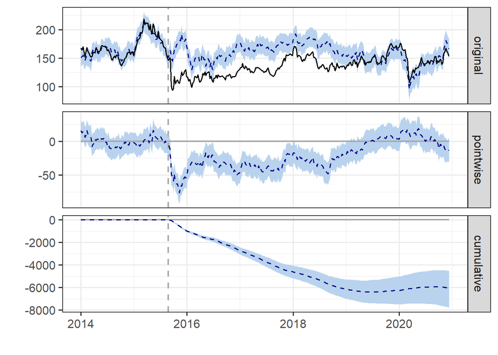

Es estos gráficos es facilmete identificable como los valores de las acciones de Volswagen disminuyeron desde la fecha del “dieselgate”

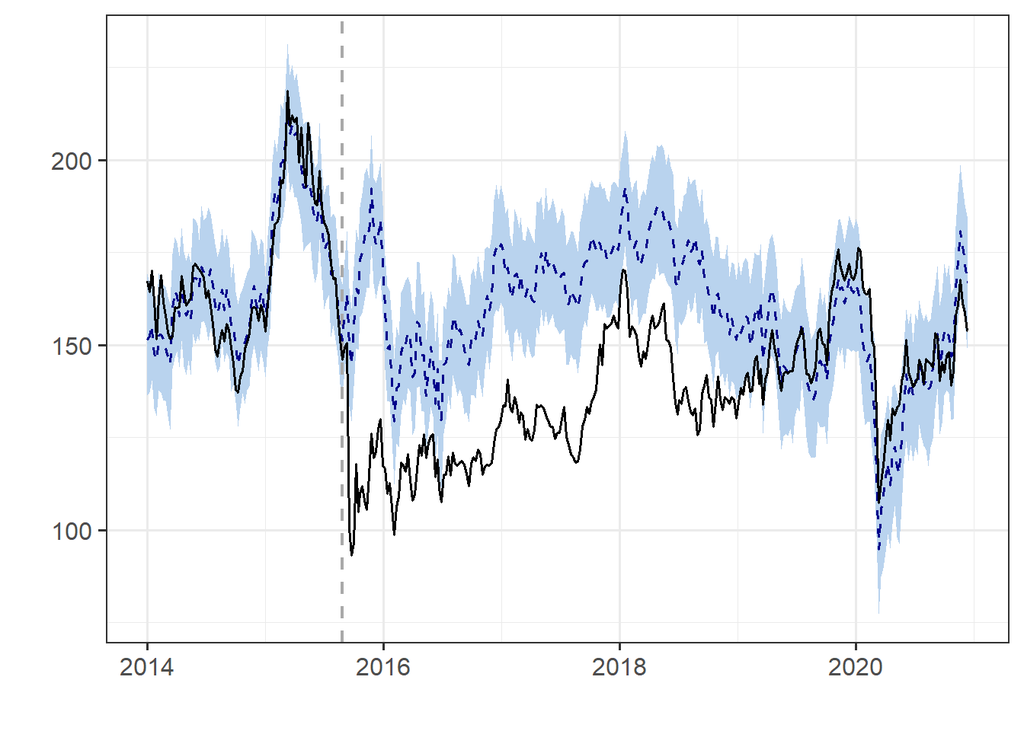

Este gráfico nos muestra la diferencia entre las predicciones d elaos valores de las acciones (línea discontinua), y los valores reales(lineas continuas). Se observa como en el momento de dieselgate los valores reales cayeron muy por debajo de los valores predecidos. es decir el dieselgate tuvo un efecto negativo para los valroes de las acciones de Volskwagen.

[output not shown]

## Causal Impact BMW

Vamos a observar digfrentes medidas y gradficos para poder interpretar cueles fueron los efectos del impacto del acontecimiento “dieselgate” para BMW. Aunque el escándolo estab relacionado con otra compaía vamos a estudiar si este hecho afecto a BMW

```
## Posterior inference {CausalImpact}
##
##                          Average       Cumulative
## Actual                   67            18490
## Prediction (s.d.)        60 (1.4)      16648 (388.5)
## 95% CI                   [58, 63]      [15930, 17456]
##
## Absolute effect (s.d.)   6.6 (1.4)     1841.3 (388.5)
## 95% CI                   [3.7, 9.2]    [1033.9, 2559.9]
##
## Relative effect (s.d.)   11% (2.3%)    11% (2.3%)
## 95% CI                   [6.2%, 15%]   [6.2%, 15%]
##
## Posterior tail-area probability p:   0.00111
## Posterior prob. of a causal effect:  99.88889%
##
## For more details, type: summary(impact, "report")
```

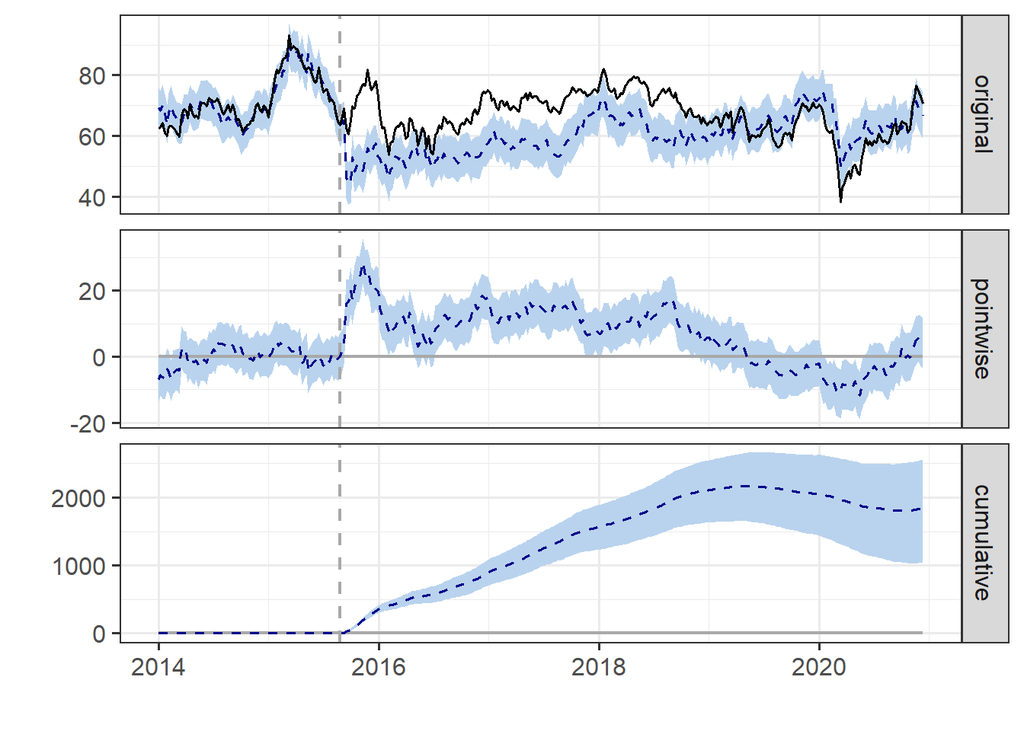

Estos graficos nos muestran el comportamiento de los activos de BMW desde el breakpoint descrito, se representa graficamente ese aumento de 11% acomulado en el valor de las acciones.

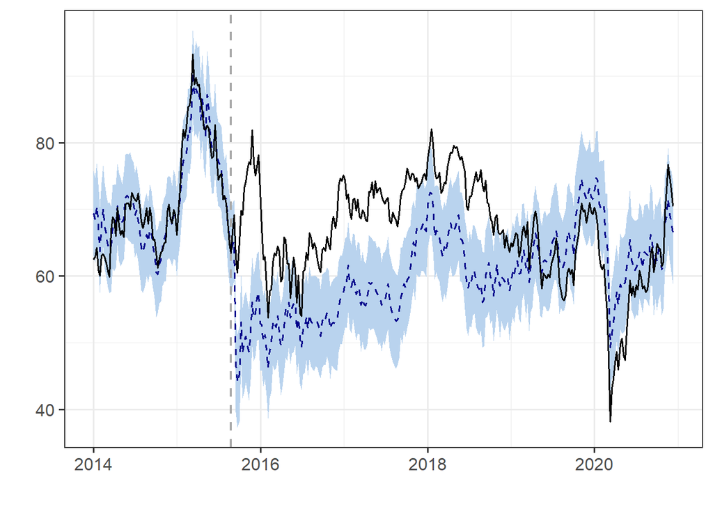

Analizado este gráfico se puede observar como los valores reales de los activos (línea continua) de BMW después del “dieselgate” fueron mayores que lo esperado (línea discontínua). Tras estos datos e interpretaciones podemos concluir que el Causal Impact de diesel gate tuvoun impactivo positivo para los activos de BMW

[output not shown]

## Conclusiones:

El objetivo era estimar estudiar el efecto del DieselGate mediante el modelo CausalImpact. Las conclusiones nos llevan a que este hecho tuvo un efecto negativo en los valores de las acciones de la compañía involucrada directamente, Volskwagen, ya que disminuyeron sus valores. Y por el contrario, el acontecimiento se tradujo en un impacto positivo para una de las compañias de la competencia como puede ser BMW, ya que los valores de sus activos se incrementaron aa partir de este hecho.